# ARE BOYS INNATELY BETTER AT MATH AND DO SPORTS POSITIVELY IMPACT STUDENTS’ ACADEMIC SUCCESS?

Research team: Andrii Ahitoliev, Ihor Ivanyshyn, Anastasiia Martsinkovska

For the fisrt part of our team’s research, we studied the differences in academic performance of boys and girls in highschools. Here we are testing the H0 (base hypothesis, that states no difference between two genders in math) vs. H1 which indicates that boys are performing better at math.

The dataset set we are using has numerous columns, but we are most interested in “Gender”, “MathScore”, “ReadingScore”, “WritingScore” and “PracticeSport”.

```r
library(ggplot2)
students_data <- read.csv("Expanded_data_with_more_features.csv", stringsAsFactors = F)

str(students_data)
```

```
## 'data.frame':    30641 obs. of  15 variables:
##  $ X                  : int  0 1 2 3 4 5 6 7 8 9 ...
##  $ Gender             : chr  "female" "female" "female" "male" ...
##  $ EthnicGroup        : chr  "" "group C" "group B" "group A" ...
##  $ ParentEduc         : chr  "bachelor's degree" "some college" "master's degree" "associate's degree" ...
##  $ LunchType          : chr  "standard" "standard" "standard" "free/reduced" ...
##  $ TestPrep           : chr  "none" "" "none" "none" ...
##  $ ParentMaritalStatus: chr  "married" "married" "single" "married" ...
##  $ PracticeSport      : chr  "regularly" "sometimes" "sometimes" "never" ...
##  $ IsFirstChild       : chr  "yes" "yes" "yes" "no" ...
##  $ NrSiblings         : int  3 0 4 1 0 1 1 1 3 NA ...
##  $ TransportMeans     : chr  "school_bus" "" "school_bus" "" ...
##  $ WklyStudyHours     : chr  "< 5" "5 - 10" "< 5" "5 - 10" ...
##  $ MathScore          : int  71 69 87 45 76 73 85 41 65 37 ...
##  $ ReadingScore       : int  71 90 93 56 78 84 93 43 64 59 ...
##  $ WritingScore       : int  74 88 91 42 75 79 89 39 68 50 ...
```

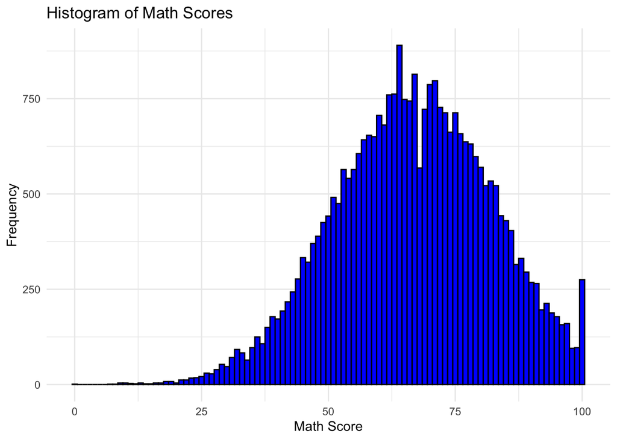

```r
ggplot(students_data, aes(x = MathScore)) +
  geom_histogram(binwidth = 1, fill = 'blue', color = 'black') +
  labs(title = "Histogram of Math Scores", x = "Math Score", y = "Frequency") +
  theme_minimal()
```

```r
summary(students_data$MathScore[students_data$Gender == 'male'])
```

```
##    Min. 1st Qu.  Median    Mean 3rd Qu.    Max.
##    7.00   59.00   69.00   69.07   80.00  100.00
```

```r
summary(students_data$MathScore[students_data$Gender == 'female'])
```

```
##    Min. 1st Qu.  Median    Mean 3rd Qu.    Max.
##    0.00   54.00   64.00   64.08   75.00  100.00
```

```r
t_test_result <- t.test(MathScore ~ Gender, data = students_data, var.equal = FALSE)

print(t_test_result)
```

```
##
##  Welch Two Sample t-test
##
## data:  MathScore by Gender
## t = -28.809, df = 30639, p-value < 2.2e-16
## alternative hypothesis: true difference in means between group female and group male is not equal to 0
## 95 percent confidence interval:
##  -5.328643 -4.649762
## sample estimates:
## mean in group female   mean in group male
##             64.08065             69.06986
```

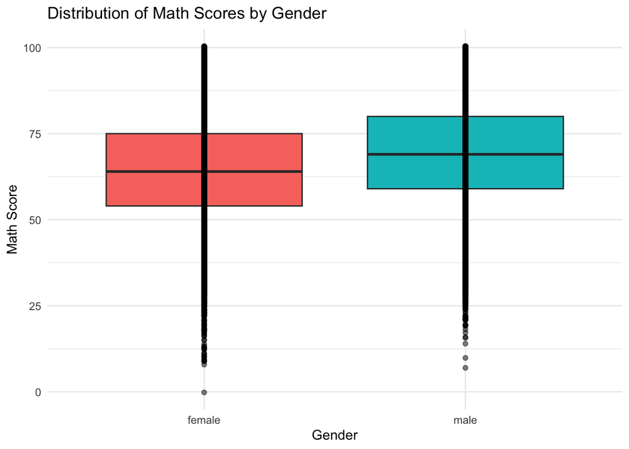

```r
ggplot(students_data, aes(x = Gender, y = MathScore, fill = Gender)) +
  geom_boxplot(outlier.shape = NA) +
  geom_jitter(position = position_jitter(0), alpha = 0.5) +
  labs(title = "Distribution of Math Scores by Gender", x = "Gender", y = "Math Score") +
  theme_minimal() +
  theme(legend.position="none")
```

From the given t-test results, we can make the following conclusions:

The t-statistic is -28.809. The negative sign indicates that the mean of the first group (female) is less than the mean of the second group (male).

The p-value is less than 2.2e-16, which is practically zero. This is less than the common significance level of 0.05. Therefore, we reject the null hypothesis (H0) that there is no difference in means between the two groups. This suggests that there is a statistically significant difference in math scores between boys and girls.

The mean math score for girls is 64.08065 and for boys is 69.06986. This indicates that, on average, boys scored higher than girls in this dataset.

However, it’s important to note that these results are based on the data at hand and the specific statistical test used. They do not prove that one gender is innately better at math than the other.

```r
library(tidyverse)
students_data$PracticeSport <- recode(students_data$PracticeSport, "never" = 0, "sometimes" = 1, "regularly" = 2)
students_data$average_exam_score <- rowMeans(students_data[,c("MathScore", "ReadingScore", "WritingScore")])

library(lmtest)
model <- lm(average_exam_score ~ PracticeSport, data = students_data)
summary(model)
```

```
##
## Call:
## lm(formula = average_exam_score ~ PracticeSport, data = students_data)
##
## Residuals:
##     Min      1Q  Median      3Q     Max
## -60.167  -9.808   0.192  10.525  32.552
##
## Coefficients:
##               Estimate Std. Error t value Pr(>|t|)
## (Intercept)    66.4483     0.1748  380.04   <2e-16 ***
## PracticeSport   1.3596     0.1254   10.85   <2e-16 ***
## ---
## Signif. codes:  0 '***' 0.001 '**' 0.01 '*' 0.05 '.' 0.1 ' ' 1
##
## Residual standard error: 14.44 on 30008 degrees of freedom
##   (631 observations deleted due to missingness)
## Multiple R-squared:  0.003905,   Adjusted R-squared:  0.003872
## F-statistic: 117.6 on 1 and 30008 DF,  p-value: < 2.2e-16
```

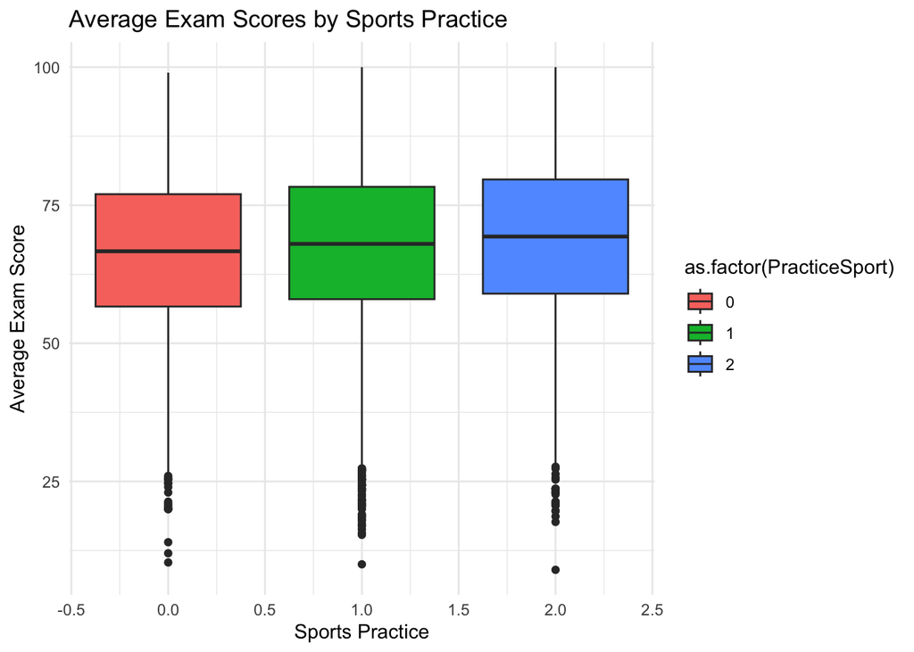

```r
ggplot(students_data, aes(x = PracticeSport, y = average_exam_score, fill = as.factor(PracticeSport))) +
  geom_boxplot() +
  labs(title = "Average Exam Scores by Sports Practice",
       x = "Sports Practice",
       y = "Average Exam Score") +
  theme_minimal()
```

In this study, we explored the relationship between sports practice and average exam scores among students. The dataset includes information on students’ math, reading, and writing scores, as well as their level of sports practice categorized as “never,” “sometimes,” or “regularly.”

To begin, we applied label encoding to the “PracticeSport” column, transforming categorical values into numerical representations: “never” as 0, “sometimes” as 1, and “regularly” as 2.

Next, we computed the average exam score for each student by taking the mean of their math, reading, and writing scores. This new variable, “average_exam_score,” served as our response variable.

We employed linear regression to investigate the relationship between sports practice and average exam scores. The linear model indicated a statistically significant association (p < 0.05) between sports practice and average exam scores. The summary statistics of the model are presented below:

The results revealed that the average exam scores differed significantly among students with different levels of sports practice. To visualize this relationship, a boxplot was created, displaying the distribution of average exam scores for each category of sports practice.

In conclusion, our analysis suggests a positive correlation between sports practice and academic performance, as reflected in average exam scores. However, it’s essential to interpret these findings cautiously, considering potential confounding variables and the limitations of observational data. Further research and a more extensive dataset could provide deeper insights into the complex interplay between sports engagement and educational outcomes.s